# Reproducible Research: Peer Assessment 1

This report is on activities of a person that is captured via a device for two month every 5 minutes. This report will explore these data and perform some basic data analysis on them.

## Loading and preprocessing the data

### Loading required libraries

```r
#install.packages("ggplot2")
library(ggplot2)
library(gridExtra)
```

### Downloading data

Data are downloaded from http://d396qusza40orc.cloudfront.net/repdata%2Fdata%2Factivity.zip. The link is to a zip file that contains a single csv file namely, activity.csv. The file is assumed to be downloaded and extratced to the working directory of this application prior to generating the report.

```r
setwd(".")
```

### Loading activities data

```r
activities=read.csv(unz(description ="activity.zip", "activity.csv"), sep=",")
str(activities)
```

```
## 'data.frame':    17568 obs. of  3 variables:
##  $ steps   : int  NA NA NA NA NA NA NA NA NA NA ...
##  $ date    : Factor w/ 61 levels "2012-10-01","2012-10-02",..: 1 1 1 1 1 1 1 1 1 1 ...
##  $ interval: int  0 5 10 15 20 25 30 35 40 45 ...
```

### Changing the date and interval format

```r
#proper date format
activities$date = as.Date(activities$date, format="%Y-%m-%d")
#date into a factor
activities$fdate = factor(activities$date)
#interval into a factor
activities$finterval = factor(activities$interval)
```

## What is mean total number of steps taken per day?

```r
sumData=tapply(activities$steps, activities$fdate,sum, na.rm=TRUE)
sum = data.frame(dimnames(sumData),sumData)
names(sum)=c("Date", "Steps")
```

```r
#Render to the a png file
png(filename=".//figure/Total_number_of_steps_per_day.png", width = 480, height = 480, units = "px", pointsize = 12, bg = "white", res = NA, family = "", restoreConsole = TRUE)
ggplot(data = sum, aes(Steps), ordered=TRUE) + geom_histogram(origin = 0, binwidth=5000, aes(fill = ..count..)) +
  ggtitle("Total Number of Steps Taken Per Day")

dev.off()
```

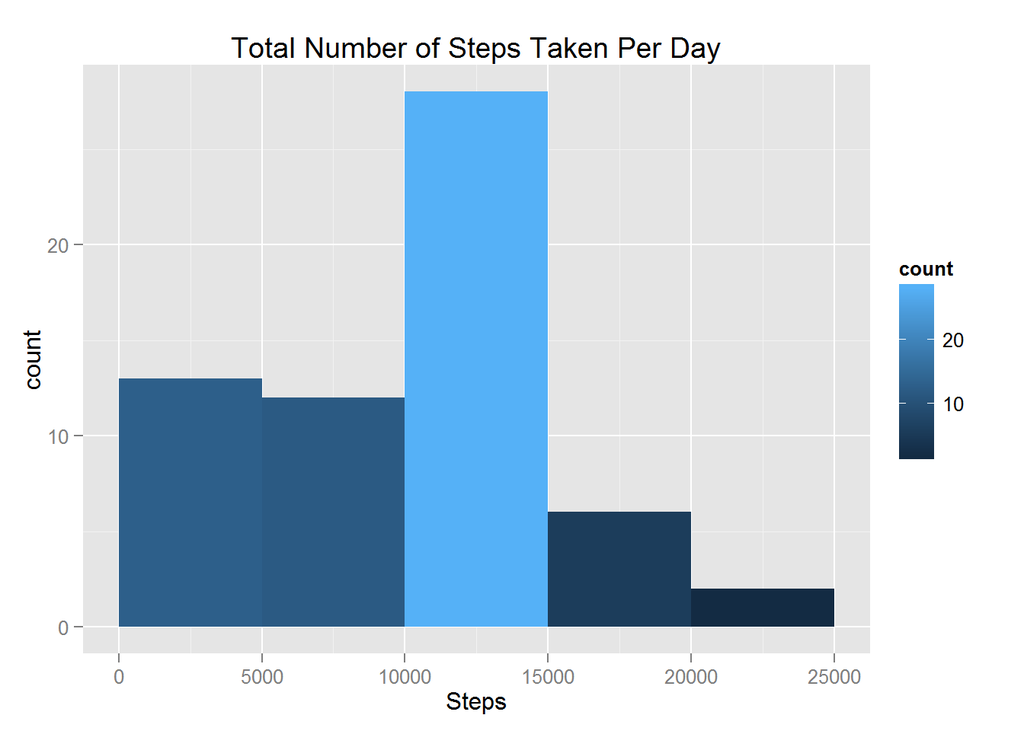

```r
#Render to report
ggplot(data = sum, aes(Steps), ordered=TRUE) + geom_histogram(origin = 0, binwidth=5000, aes(fill = ..count..)) +
  ggtitle("Total Number of Steps Taken Per Day")
```

### The mean and median

```r
oldMean = mean(sumData, na.rm = TRUE)
oldMedian = median(sumData, na.rm = TRUE)
```

The mean is `9354.2295` The median is `10395`

## What is the average daily activity pattern?

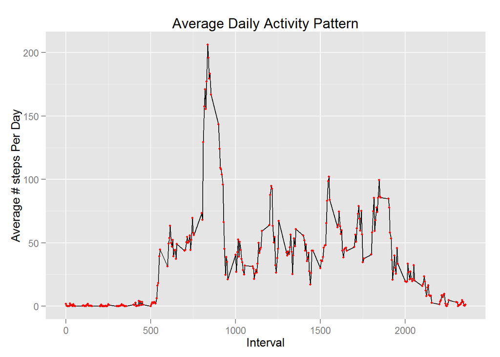

```r
avgData=tapply(activities$steps, activities$interval,mean, na.rm=TRUE)
avg = data.frame(dimnames(avgData),avgData)
names(avg)=c("Interval", "Activities")
#png(filename=".//figure/Average_Daily_Activity_Pattern.png", width = 480, height = 480, units = "px", pointsize = 12, bg = "white", res = NA, family = "", restoreConsole = TRUE)

ggplot(data= avg, aes(x = as.numeric(as.character(Interval)), y = Activities), ordered=TRUE) + geom_line() + geom_point(colour = 'red', size = 1)+
  xlab("Interval") +
  ylab("Average # steps Per Day") +
  ggtitle("Average Daily Activity Pattern")
```

```r
  #xlim(0,5000)

#dev.off()
```

```r
intervalOfMaxAverageStepsNo_Index = which.max(avg$Activities)
intervalOfMaxAverageStepsNo_Value = max(avg$Activities)
```

The maximum value is @ 104 and its value is 206.1698

## Imputing missing values

```r
missingActivities = activities[is.na(activities$steps),]
missingActivitiesNO=length(missingActivities$steps)
activitiesNO =  length(activities$steps)
```

### Filling of missing values in the dataset:

In this analysis, I will substitute the missing values with the mean value of that interval across all days in the study.

```r
names(avg)=c("interval", "averageStepsByInterval")
averagedActivitiesByIntertval=merge(activities, avg, by.x="interval",by.y="interval")
missingActivitiesIndices = which(is.na(averagedActivitiesByIntertval$steps))
averagedActivitiesByIntertval[missingActivitiesIndices,2] = averagedActivitiesByIntertval[missingActivitiesIndices,6]
correctedActivities = averagedActivitiesByIntertval[,1:5]
```

### Graph of the corrected activities of the total number of steps taken each day

```r
correctedSumData=tapply(correctedActivities$steps, correctedActivities$fdate,sum, na.rm=TRUE)
png(filename=".//figure/Total_number_of_steps_per_day_(Histogram)(corrected).png", width = 480, height = 480, units = "px", pointsize = 12, bg = "white", res = NA, family = "", restoreConsole = TRUE)
correctedSum = data.frame(dimnames(correctedSumData),correctedSumData)
names(correctedSum)=c("Date", "Steps")
#hist(correctedSumData)

ggplot(data = correctedSum, aes(Steps), ordered=TRUE) + geom_histogram(origin = 0, binwidth=5000, aes(fill = ..count..)) +
ggtitle("Total Number of Steps Taken Per Day")

dev.off()
```

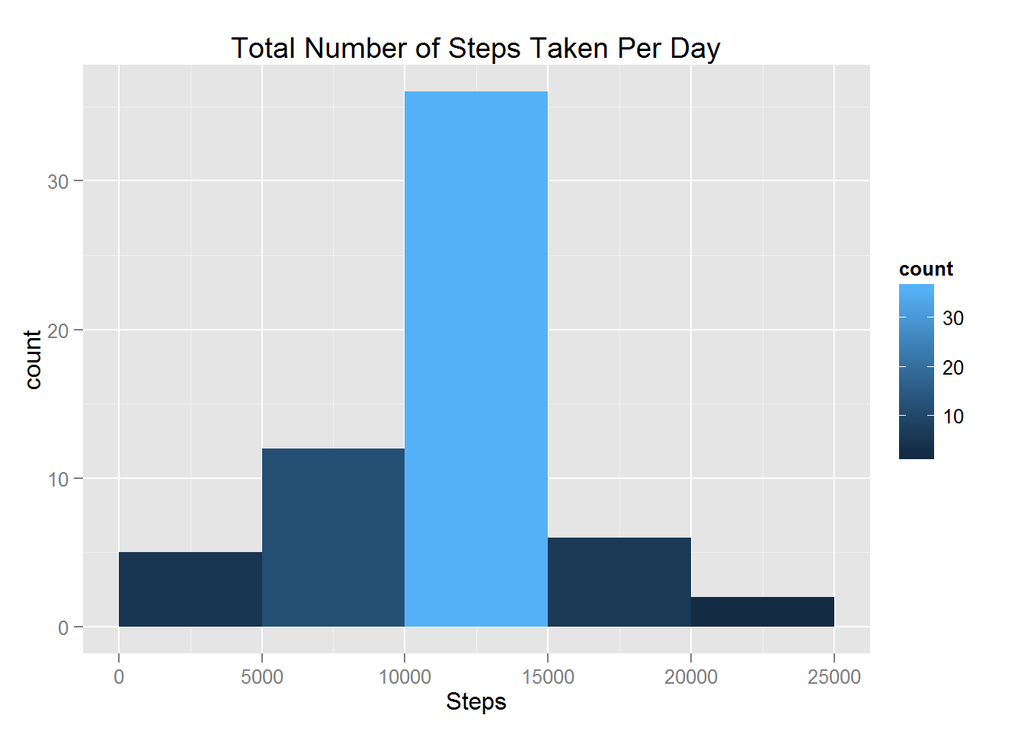

```r
ggplot(data = correctedSum, aes(Steps), ordered=TRUE) + geom_histogram(origin = 0, binwidth=5000, aes(fill = ..count..)) +
ggtitle("Total Number of Steps Taken Per Day")
```

```r
png(filename=".//figure/Total_number_of_steps_per_day_(corrected).png", width = 480, height = 480, units = "px", pointsize = 12, bg = "white", res = NA, family = "", restoreConsole = TRUE)
ggplot(data = correctedSum, aes(x=as.Date(Date), y=Steps), ordered=TRUE) + geom_line() + geom_point()+
  labs(x = "Month", y = " Total Number of Steps Taken Each Day")
dev.off()
```

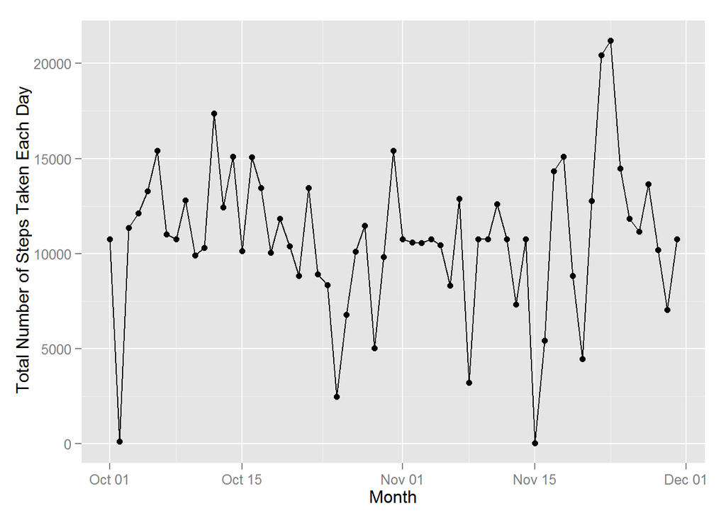

```r
ggplot(data = correctedSum, aes(x=as.Date(Date), y=Steps), ordered=TRUE) + geom_line() + geom_point()+
  labs(x = "Month", y = " Total Number of Steps Taken Each Day")
```

### The mean and median of the corrected activities

```r
newMean = mean(correctedSumData, na.rm = TRUE)
newMedian = median(correctedSumData, na.rm = TRUE)
```

#### Do these values differ from the estimates from the first part of the assignment?

Yes they differ, the mean and median have increased slightly  
Old values vs New Values old Mean 9354.2295 New Mean 1.0766 × 10<sup>4</sup> old Median 10395 New Median 1.0766 × 10<sup>4</sup>

#### What is the impact of imputing missing data on the estimates of the total daily number of steps?

The distribution of the data has changed a little. There is an increase in the frequency of the number of steps in general. The maxima of the number of steps is has remained the same while the minima have definitely increased. the mean and median have increased slightly.

## Are there differences in activity patterns between weekdays and weekends?

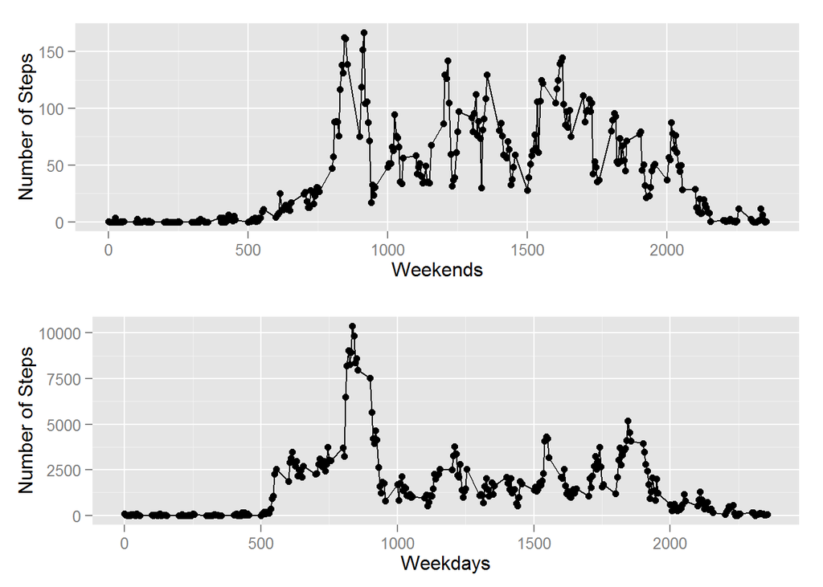

```r
correctedActivities$day = ifelse(weekdays(as.Date(correctedActivities$date)) %in% c("Saturday", "Sunday"), "Weekend", "Weekday")
weekdaysSubset = subset(correctedActivities, correctedActivities$day == "Weekday")
weekendsSubset = subset(correctedActivities, correctedActivities$day == "Weekend")
Weekdays=tapply(weekdaysSubset$steps, weekdaysSubset$interval,sum, na.rm=TRUE)
correctedWeekdays = data.frame(dimnames(Weekdays),Weekdays)
names(correctedWeekdays)=c("Interval", "Steps")

Weekends=tapply(weekendsSubset$steps, weekendsSubset$interval,mean, na.rm=TRUE)
correctedWeekends = data.frame(dimnames(Weekends),Weekends)
names(correctedWeekends)=c("Interval", "Steps")

a1 = qplot(x=as.numeric(as.character(Interval)), y=Steps, data = correctedWeekdays,  ordered=TRUE) + geom_line() + geom_point() +
  labs(x = "Weekdays", y = "Number of Steps")
a2 = qplot(x=as.numeric(as.character(Interval)), y=Steps, data = correctedWeekends, ordered=TRUE) + geom_line() + geom_point()+
  labs(x = "Weekends", y = "Number of Steps")
grid.arrange(a2, a1, nrow=2)
```